# House Selling Prices

## The Goal

To build a Regression Model from House Data that predicts it’s selling price while meeting the following criteria:

1. Having an Adjusted R-squared greater than 0.86 and a validation Adjusted R-squared greater than 0.83
2. Creating a visualization of the model
3. Creating a interpretation of the model

## Regression

### Exploring the Data

I took some time here to explore the data, creating factors and separating them out factors into individuals terms to see what stood out in a full regression. This pathway gave me an adjusted R-squared of 0.9367, however the validation was terrible. I then began to refine the model through a painful process of visualization and trial and error. A sample of my code during this process will be shown below.

```r
# Wrangle the Data
houses$Street <- factor(houses$Street,
                       levels = levels(houses$Street),
                       # ("Grvl" "Pave")
                       labels = c(1:nlevels(houses$Street)))

houses$MSZoning <- factor(houses$MSZoning,
                       levels = levels(houses$MSZoning),
                       # "C (all)" "FV"      "RH"      "RL"      "RM"
                       labels = c(1:nlevels(houses$MSZoning)))

houses$LotConfig <- factor(houses$LotConfig,
                       levels = levels(houses$LotConfig),
                       # "Corner"  "CulDSac" "FR2"     "FR3"     "Inside"
                       labels = c(1:nlevels(houses$LotConfig)))

houses$LotShape <- factor(houses$LotShape,
                       levels = levels(houses$LotShape),
                       # "IR1" "IR2" "IR3" "Reg"
                       labels = c(1:nlevels(houses$LotShape)))

houses$Neighborhood <- factor(houses$Neighborhood,
                       levels = levels(houses$Neighborhood),
                       # "Blmngtn" "Blueste" "BrDale"  "BrkSide" "ClearCr" "CollgCr" "Crawfor" "Edwards" "Gilbert" "IDOTRR"  "MeadowV" "Mitchel" "NAmes"   "NoRidge" "NPkVill" "NridgHt" "NWAmes"  "OldTown" "Sawyer"  "SawyerW" "Somerst" "StoneBr" "SWISU"   "Timber"  "Veenker"
                       labels = c(1:nlevels(houses$Neighborhood)))

houses$LandContour <- factor(houses$LandContour,
                       levels = levels(houses$LandContour),
                       # "Bnk" "HLS" "Low" "Lvl"
                       labels = c(1:nlevels(houses$LandContour)))

houses$LandSlope <- factor(houses$LandSlope,
                       levels = levels(houses$LandSlope),
                       # "Gtl" "Mod" "Sev"
                       labels = c(1:nlevels(houses$LandSlope)))

houses$Condition1 <- factor(houses$Condition1,
                       levels = levels(houses$Condition1),
                       # "Artery" "Feedr"  "Norm"   "PosA"   "PosN"   "RRAe"   "RRAn"   "RRNe"   "RRNn"
                       labels = c(1:nlevels(houses$Condition1)))

houses$Condition2 <- factor(houses$Condition2,
                       levels = levels(houses$Condition2),
                       # "Artery" "Feedr"  "Norm"   "PosA"   "PosN"   "RRAe"   "RRAn"   "RRNn"
                       labels = c(1:nlevels(houses$Condition2)))

houses$BldgType <- factor(houses$BldgType,
                       levels = levels(houses$BldgType),
                       # "1Fam"   "2fmCon" "Duplex" "Twnhs"  "TwnhsE"
                       labels = c(1:nlevels(houses$BldgType)))

houses$HouseStyle <- factor(houses$HouseStyle,
                       levels = levels(houses$HouseStyle),
                       # "1.5Fin" "1.5Unf" "1Story" "2.5Unf" "2Story" "SFoyer" "SLvl"
                       labels = c(1:nlevels(houses$HouseStyle)))

houses$RoofStyle <- factor(houses$RoofStyle,
                       levels = levels(houses$RoofStyle),
                       # "Flat"    "Gable"   "Gambrel" "Hip"     "Mansard" "Shed"
                       labels = c(1:nlevels(houses$RoofStyle)))

houses$RoofMatl <- factor(houses$RoofMatl,
                       levels = levels(houses$RoofMatl),
                       # "CompShg" "Tar&Grv" "WdShake" "WdShngl"
                       labels = c(1:nlevels(houses$RoofMatl)))

houses$Exterior1st <- factor(houses$Exterior1st,
                       levels = levels(houses$Exterior1st),
                       # "AsbShng" "AsphShn" "BrkComm" "BrkFace" "CBlock"  "CemntBd" "HdBoard" "MetalSd" "Plywood" "Stucco"  "VinylSd" "Wd Sdng" "WdShing"
                       labels = c(1:nlevels(houses$Exterior1st)))

houses$Exterior2nd <- factor(houses$Exterior2nd,
                       levels = levels(houses$Exterior2nd),
                       # "AsbShng" "AsphShn" "Brk Cmn" "BrkFace" "CBlock"  "CmentBd" "HdBoard" "ImStucc" "MetalSd" "Other"   "Plywood" "Stone"   "Stucco"  "VinylSd" "Wd Sdng" "Wd Shng"
                       labels = c(1:nlevels(houses$Exterior2nd)))

houses$MasVnrType <- factor(houses$MasVnrType,
                       levels = levels(houses$MasVnrType),
                       # "BrkCmn"  "BrkFace" "None"  "Stone"
                       labels = c(1:nlevels(houses$MasVnrType)))

houses$ExterQual <- factor(houses$ExterQual,
                       levels = levels(houses$ExterQual),
                       # "Ex" "Fa" "Gd" "TA"
                       labels = c(1:nlevels(houses$ExterQual)))

houses$ExterCond <- factor(houses$ExterCond,
                       levels = levels(houses$ExterCond),
                       # "Ex" "Fa" "Gd" "Po" "TA"
                       labels = c(1:nlevels(houses$ExterCond)))

houses$BsmtQual <- factor(houses$BsmtQual,
                       levels = levels(houses$BsmtQual),
                       # "Ex" "Fa" "Gd" "TA"
                       labels = c(1:nlevels(houses$BsmtQual)))

houses$BsmtCond <- factor(houses$BsmtCond,
                       levels = levels(houses$BsmtCond),
                       # "Fa" "Gd" "Po" "TA"
                       labels = c(1:nlevels(houses$BsmtCond)))

houses$Foundation <- factor(houses$Foundation,
                       levels = levels(houses$Foundation),
                       # "BrkTil" "CBlock" "PConc"  "Slab"   "Stone"  "Wood"
                       labels = c(1:nlevels(houses$Foundation)))

houses$BsmtExposure <- factor(houses$BsmtExposure,
                       levels = levels(houses$BsmtExposure),
                       # "Av" "Gd" "Mn" "No"
                       labels = c(1:nlevels(houses$BsmtExposure)))

houses$BsmtFinType1 <- factor(houses$BsmtFinType1,
                       levels = levels(houses$BsmtFinType1),
                       # "ALQ" "BLQ" "GLQ" "LwQ" "Rec" "Unf"
                       labels = c(1:nlevels(houses$BsmtFinType1)))

houses$BsmtFinType2 <- factor(houses$BsmtFinType2,
                       levels = levels(houses$BsmtFinType2),
                       # "ALQ" "BLQ" "GLQ" "LwQ" "Rec" "Unf"
                       labels = c(1:nlevels(houses$BsmtFinType2)))
```

```r
houses$Heating <- factor(houses$Heating,
                       levels = levels(houses$Heating),
                       # "GasA" "GasW" "Grav" "Wall"
                       labels = c(1:nlevels(houses$Heating)))

houses$HeatingQC <- factor(houses$HeatingQC,
                       levels = levels(houses$HeatingQC),
                       # "Ex" "Fa" "Gd" "Po" "TA"
                       labels = c(1:nlevels(houses$HeatingQC)))

houses$CentralAir <- factor(houses$CentralAir,
                       levels = levels(houses$CentralAir),
                       # "N" "Y"
                       labels = c(1:nlevels(houses$CentralAir)))

houses$Electrical <- factor(houses$Electrical,
                       levels = levels(houses$Electrical),
                       # "FuseA" "FuseF" "FuseP" "SBrkr"
                       labels = c(1:nlevels(houses$Electrical)))

houses$Alley <- as.character(houses$Alley)
houses$Alley <- replace_na(houses$Alley, "No alley access")
houses$Alley <- as.factor(houses$Alley)
houses$Alley <- factor(houses$Alley,
                       levels = levels(houses$Alley),
                       # "Grvl" "Pave" "NA"
                       labels = c(1:nlevels(houses$Alley)))

houses$KitchenQual <- factor(houses$KitchenQual,
                       levels = levels(houses$KitchenQual),
                       # "Ex" "Fa" "Gd" "TA"
                       labels = c(1:nlevels(houses$KitchenQual)))

houses$Functional <- factor(houses$Functional,
                       levels = levels(houses$Functional),
                       # "Maj1" "Maj2" "Min1" "Min2" "Mod"  "Sev"  "Typ"
                       labels = c(1:nlevels(houses$Functional)))

houses$FireplaceQu <- as.character(houses$FireplaceQu)
houses$FireplaceQu <- replace_na(houses$FireplaceQu, "No Fireplace")
houses$FireplaceQu <- as.factor(houses$FireplaceQu)
houses$FireplaceQu <- factor(houses$FireplaceQu,
                       levels = levels(houses$FireplaceQu),
                       # "Ex" "Fa" "Gd" "No Fireplace" "Po" "TA"
                       labels = c(1:nlevels(houses$FireplaceQu)))

houses$GarageType <- as.character(houses$GarageType)
houses$GarageType <- replace_na(houses$GarageType, "No Garage")
houses$GarageType <- as.factor(houses$GarageType)
houses$GarageType <- factor(houses$GarageType,
                       levels = levels(houses$GarageType),
                       # "2Types"    "Attchd"    "Basment"   "BuiltIn"   "CarPort"   "Detchd"    "No Garage"
                       labels = c(1:nlevels(houses$GarageType)))

houses$GarageFinish <- as.character(houses$GarageFinish)
houses$GarageFinish <- replace_na(houses$GarageFinish, "No Garage")
houses$GarageFinish <- as.factor(houses$GarageFinish)
houses$GarageFinish <- factor(houses$GarageFinish,
                       levels = levels(houses$GarageFinish),
                       # "Fin"       "No Garage" "RFn"       "Unf"
                       labels = c(1:nlevels(houses$GarageFinish)))

houses$GarageQual <- as.character(houses$GarageQual)
houses$GarageQual <- replace_na(houses$GarageQual, "No Garage")
houses$GarageQual <- as.factor(houses$GarageQual)
houses$GarageQual <- factor(houses$GarageQual,
                       levels = levels(houses$GarageQual),
                       # "Ex"        "Fa"        "Gd"        "No Garage" "Po"        "TA"
                       labels = c(1:nlevels(houses$GarageQual)))

houses$GarageCond <- as.character(houses$GarageCond)
houses$GarageCond <- replace_na(houses$GarageCond, "No Garage")
houses$GarageCond <- as.factor(houses$GarageCond)
houses$GarageCond <- factor(houses$GarageCond,
                       levels = levels(houses$GarageCond),
                       # "Ex"        "Fa"        "Gd"        "No Garage" "Po"        "TA"
                       labels = c(1:nlevels(houses$GarageCond)))

houses$PavedDrive <- factor(houses$PavedDrive,
                       levels = levels(houses$PavedDrive),
                       # "N" "P" "Y"
                       labels = c(1:nlevels(houses$PavedDrive)))

houses$PoolQC <- as.character(houses$PoolQC)
houses$PoolQC <- replace_na(houses$PoolQC, "No Pool")
houses$PoolQC <- as.factor(houses$PoolQC)
houses$PoolQC <- factor(houses$PoolQC,
                       levels = levels(houses$PoolQC),
                       # ""Ex"      "Fa"      "Gd"      "No Pool"
                       labels = c(1:nlevels(houses$PoolQC)))

houses$Fence <- as.character(houses$Fence)
houses$Fence <- replace_na(houses$Fence, "No Fence")
houses$Fence <- as.factor(houses$Fence)
houses$Fence <- factor(houses$Fence,
                       levels = levels(houses$Fence),
                       # "GdPrv"    "GdWo"     "MnPrv"    "MnWw"     "No Fence"
                       labels = c(1:nlevels(houses$Fence)))

houses$MiscFeature <- as.character(houses$MiscFeature)
houses$MiscFeature <- replace_na(houses$MiscFeature, "No MISC")
houses$MiscFeature <- as.factor(houses$MiscFeature)
houses$MiscFeature <- factor(houses$MiscFeature,
                       levels = levels(houses$MiscFeature),
                       # "Gar2"    "No MISC" "Othr"    "Shed"    "TenC"
                       labels = c(1:nlevels(houses$MiscFeature)))

houses$SaleType <- factor(houses$SaleType,
                       levels = levels(houses$SaleType),
                       # COD"   "Con"   "ConLD" "ConLI" "ConLw" "CWD"   "New"   "Oth"   "WD"
                       labels = c(1:nlevels(houses$SaleType)))

houses$SaleCondition <- factor(houses$SaleCondition,
                       levels = levels(houses$SaleCondition),
                       # "Abnorml" "AdjLand" "Alloca"  "Family"  "Normal"  "Partial"
                       labels = c(1:nlevels(houses$SaleCondition)))

houses$Utilities <- factor(houses$Utilities,
                       levels = levels(houses$Utilities),
                       # "AllPub" "NoSeWa"
                       labels = c(1:nlevels(houses$Utilities)))

houses <- houses[, !names(houses) %in% c("Utilities", "Id")]

houses1 <- houses %>%
  mutate(
    CmentBd = case_when(
    Exterior2nd == 6 ~ 1,
    TRUE ~ 0),
    Stone_Foundation = case_when(
    Foundation %in% 5 ~ 1,
    TRUE ~ 0),
    Wood_Foundation = case_when(
    Foundation %in% 6 ~ 1,
    TRUE ~ 0),
    Typ_Functional = case_when(
    Functional %in% 7 ~ 1,
    TRUE ~ 0),
    HeatingQC_Gd = case_when(
    HeatingQC %in% 3 ~ 1,
    TRUE ~ 0),
    HeatingQC_Ta = case_when(
    HeatingQC %in% 5 ~ 1,
    TRUE ~ 0),
    LotConfig_CulDSac = case_when(
    LotConfig %in% 2 ~ 1,
    TRUE ~ 0),
    SaleType_ConLD = case_when(
    SaleType %in% 3 ~ 1,
    TRUE ~ 0),
    Exterior1st_AsbShng = case_when(
    Exterior1st %in% 1 ~ 1,
    TRUE ~ 0),
    Exterior1st_BrkComm = case_when(
    Exterior1st %in% 3 ~ 1,
    TRUE ~ 0),
    Exterior1st_BrkFace = case_when(
    Exterior1st %in% 4 ~ 1,
    TRUE ~ 0),
    Exterior1st_CemntBd = case_when(
    Exterior1st %in% 6 ~ 1,
    TRUE ~ 0),
    Exterior1st_ImStucc = case_when(
    Exterior1st %in% 7 ~ 1,
    TRUE ~ 0),
    Exterior1st_Plywood = case_when(
    Exterior1st %in% 10 ~ 1,
    TRUE ~ 0),
    SaleCondition_Abnormal = case_when(
    SaleCondition %in% 1 ~ 1,
    TRUE ~ 0),
    SaleCondition_Alloca = case_when(
    SaleCondition %in% 3 ~ 1,
    TRUE ~ 0),
    SaleCondition_Family = case_when(
    SaleCondition %in% 4 ~ 1,
    TRUE ~ 0),
    SaleCondition_Normal = case_when(
    SaleCondition %in% 5 ~ 1,
    TRUE ~ 0),
    Neighborhood3 = case_when(
    Neighborhood %in% 3 ~ 1,
    TRUE ~ 0),
    Neighborhood4 = case_when(
    Neighborhood %in% 4 ~ 1,
    TRUE ~ 0),
    Neighborhood7 = case_when(
    Neighborhood %in% 7 ~ 1,
    TRUE ~ 0),
    Neighborhood8 = case_when(
    Neighborhood %in% 8 ~ 1,
    TRUE ~ 0),
    Neighborhood11 = case_when(
    Neighborhood %in% 11 ~ 1,
    TRUE ~ 0),
    Neighborhood16 = case_when(
    Neighborhood %in% 16 ~ 1,
    TRUE ~ 0),
    Neighborhood22 = case_when(
    Neighborhood %in% 22 ~ 1,
    TRUE ~ 0),
    Condition1_Artery = case_when(
    Condition1 %in% 1 ~ 1,
    TRUE ~ 0),
    Condition1_Feedr = case_when(
    Condition1 %in% 2 ~ 1,
    TRUE ~ 0),
    Condition1_RRAe = case_when(
    Condition1 %in% 6 ~ 1,
    TRUE ~ 0),
    Condition2_Norm = case_when(
    Condition2 %in% 3 ~ 1,
    TRUE ~ 0),
    Condition2_PosA = case_when(
    Condition2 %in% 4 ~ 1,
    TRUE ~ 0),
    Condition2_PosN = case_when(
    Condition2 %in% 5 ~ 1,
    TRUE ~ 0),
    RoofMatl = cut(as.numeric(as.character(RoofMatl)), c(0,7,8), labels = c("G1","G2")),
    MSZoning = as.factor(case_when(
      MSZoning %in% c(2,4) ~ 2,
      MSZoning %in% c(3,5) ~ 3,
      TRUE ~ as.numeric(MSZoning))
    )
    )
```

#### My Starting Point

```r
# Split the dataset into the Training set and Test set
set.seed(265)
split <- sample.split(houses1$SalePrice, SplitRatio = .8)
training_set <- subset(houses1, split == TRUE)
test_set <- subset(houses1, split == FALSE)
```

```r
summary(lm(log(SalePrice) ~ ., data = training_set))
```

```
##
## Call:
## lm(formula = log(SalePrice) ~ ., data = training_set)
##
## Residuals:
##      Min       1Q   Median       3Q      Max
## -0.63464 -0.04686  0.00137  0.04886  0.63464
##
## Coefficients: (35 not defined because of singularities)
##                          Estimate Std. Error t value Pr(>|t|)
## (Intercept)            -4.829e+00  6.219e+00  -0.776 0.437731
## MSSubClass             -3.673e-04  6.416e-04  -0.573 0.567158
## MSZoning2               4.522e-01  6.106e-02   7.405 3.68e-13 ***
## MSZoning3               4.353e-01  5.715e-02   7.617 8.24e-14 ***
## LotFrontage             5.711e-04  2.725e-04   2.096 0.036463 *
## LotArea                 2.064e-06  7.190e-07   2.871 0.004207 **
## Street2                 1.375e-01  9.970e-02   1.380 0.168161
## Alley2                 -1.537e-02  2.541e-02  -0.605 0.545387
## Alley3                 -1.904e-02  3.554e-02  -0.536 0.592287
## LotShape2               9.520e-03  2.570e-02   0.370 0.711137
## LotShape3               3.556e-02  5.641e-02   0.630 0.528611
## LotShape4               1.293e-02  9.734e-03   1.328 0.184442
## LandContour2            1.890e-02  3.022e-02   0.625 0.531850
## LandContour3           -2.310e-02  4.785e-02  -0.483 0.629479
## LandContour4            4.374e-03  2.241e-02   0.195 0.845306
## LotConfig2              6.171e-02  2.359e-02   2.615 0.009097 **
## LotConfig3             -6.187e-02  2.567e-02  -2.410 0.016188 *
## LotConfig4             -5.141e-02  7.048e-02  -0.729 0.465996
## LotConfig5             -1.056e-02  1.105e-02  -0.956 0.339495
## LandSlope2              2.174e-02  2.364e-02   0.920 0.358073
## LandSlope3             -1.478e-01  7.087e-02  -2.086 0.037334 *
## Neighborhood2          -7.269e-02  9.458e-02  -0.769 0.442433
## Neighborhood3          -3.610e-02  5.922e-02  -0.610 0.542284
## Neighborhood4           1.754e-02  5.303e-02   0.331 0.740854
## Neighborhood5           6.069e-02  5.484e-02   1.107 0.268839
## Neighborhood6           1.261e-02  3.863e-02   0.326 0.744218
## Neighborhood7           1.209e-01  4.637e-02   2.606 0.009340 **
## Neighborhood8          -6.992e-02  4.317e-02  -1.620 0.105751
## Neighborhood9          -1.740e-03  4.227e-02  -0.041 0.967184
## Neighborhood10         -1.762e-02  6.152e-02  -0.286 0.774694
```

[output cut: 222 more lines]

```
## Neighborhood16                 NA         NA      NA       NA
## Neighborhood22                 NA         NA      NA       NA
## Condition1_Artery              NA         NA      NA       NA
## Condition1_Feedr               NA         NA      NA       NA
## Condition1_RRAe                NA         NA      NA       NA
## Condition2_Norm                NA         NA      NA       NA
## Condition2_PosA                NA         NA      NA       NA
## Condition2_PosN                NA         NA      NA       NA
## ---
## Signif. codes:  0 '***' 0.001 '**' 0.01 '*' 0.05 '.' 0.1 ' ' 1
##
## Residual standard error: 0.1021 on 717 degrees of freedom
##   (316 observations deleted due to missingness)
## Multiple R-squared:  0.9518, Adjusted R-squared:  0.9367
## F-statistic: 63.21 on 224 and 717 DF,  p-value: < 2.2e-16
```

While I have a good Adjusted R-squared with this intense model containing everything. There is no way a validation of this model will work. After whittling things down a bit, I get the following model:

```r
regressor2 <- lm(log(SalePrice) ~ MSZoning + OverallCond + X2ndFlrSF + Condition2 + BsmtFinSF1 + CentralAir + LotArea + Neighborhood + SaleCondition + ScreenPorch + KitchenQual + LandSlope + Exterior1st + BsmtFullBath + SaleType + LotConfig + BsmtUnfSF + YearBuilt + HeatingQC + GarageArea + GarageQual + Functional + Foundation + BsmtFinSF2 + WoodDeckSF + GarageCars + X3SsnPorch + HalfBath + YearRemodAdd + OverallQual:I(X1stFlrSF^2) + OverallQual:I(X1stFlrSF^3), data = training_set)

summary(regressor2)
```

```
##
## Call:
## lm(formula = log(SalePrice) ~ MSZoning + OverallCond + X2ndFlrSF +
##     Condition2 + BsmtFinSF1 + CentralAir + LotArea + Neighborhood +
##     SaleCondition + ScreenPorch + KitchenQual + LandSlope + Exterior1st +
##     BsmtFullBath + SaleType + LotConfig + BsmtUnfSF + YearBuilt +
##     HeatingQC + GarageArea + GarageQual + Functional + Foundation +
##     BsmtFinSF2 + WoodDeckSF + GarageCars + X3SsnPorch + HalfBath +
##     YearRemodAdd + OverallQual:I(X1stFlrSF^2) + OverallQual:I(X1stFlrSF^3),
##     data = training_set)
##
## Residuals:
##      Min       1Q   Median       3Q      Max
## -0.63108 -0.05175  0.00162  0.05948  0.60625
##
## Coefficients:
##                              Estimate Std. Error t value Pr(>|t|)
## (Intercept)                 4.768e+00  7.298e-01   6.533 9.68e-11 ***
## MSZoning2                   5.371e-01  4.907e-02  10.945  < 2e-16 ***
## MSZoning3                   4.847e-01  4.656e-02  10.411  < 2e-16 ***
## OverallCond                 4.094e-02  4.025e-03  10.171  < 2e-16 ***
## X2ndFlrSF                   2.867e-04  1.108e-05  25.884  < 2e-16 ***
## Condition22                 9.112e-02  1.018e-01   0.895 0.370934
## Condition23                 1.871e-01  8.304e-02   2.254 0.024406 *
## Condition24                 3.205e-01  1.408e-01   2.276 0.023014 *
## Condition25                -6.480e-01  1.179e-01  -5.498 4.74e-08 ***
## Condition26                -1.470e-02  1.405e-01  -0.105 0.916649
## Condition27                 2.496e-03  1.406e-01   0.018 0.985842
## Condition28                 1.170e-01  1.157e-01   1.011 0.312117
## BsmtFinSF1                  1.987e-04  1.925e-05  10.319  < 2e-16 ***
## CentralAir2                 8.336e-02  1.677e-02   4.972 7.63e-07 ***
## LotArea                     2.553e-06  4.456e-07   5.731 1.28e-08 ***
## Neighborhood2              -8.085e-02  8.662e-02  -0.933 0.350763
## Neighborhood3              -1.149e-01  4.641e-02  -2.475 0.013464 *
## Neighborhood4               3.938e-02  3.809e-02   1.034 0.301389
## Neighborhood5               6.588e-02  3.924e-02   1.679 0.093421 .
## Neighborhood6               6.006e-03  2.947e-02   0.204 0.838539
## Neighborhood7               1.332e-01  3.649e-02   3.649 0.000275 ***
## Neighborhood8              -5.491e-02  3.336e-02  -1.646 0.100059
## Neighborhood9               2.778e-02  3.172e-02   0.876 0.381337
```

[output cut: 76 more lines]

```
## Foundation6                -1.582e-01  8.391e-02  -1.885 0.059631 .
## BsmtFinSF2                  1.703e-04  2.631e-05   6.473 1.42e-10 ***
## WoodDeckSF                  8.872e-05  2.826e-05   3.139 0.001737 **
## GarageCars                  2.918e-02  1.105e-02   2.640 0.008391 **
## X3SsnPorch                  2.193e-04  1.263e-04   1.737 0.082696 .
## HalfBath                    1.368e-02  9.112e-03   1.501 0.133562
## YearRemodAdd                7.682e-04  2.637e-04   2.913 0.003651 **
## OverallQual:I(X1stFlrSF^2)  3.617e-08  1.425e-09  25.381  < 2e-16 ***
## OverallQual:I(X1stFlrSF^3) -9.347e-12  3.170e-13 -29.482  < 2e-16 ***
## ---
## Signif. codes:  0 '***' 0.001 '**' 0.01 '*' 0.05 '.' 0.1 ' ' 1
##
## Residual standard error: 0.1097 on 1150 degrees of freedom
## Multiple R-squared:  0.9348, Adjusted R-squared:  0.9287
## F-statistic:   154 on 107 and 1150 DF,  p-value: < 2.2e-16
```

```r
y_pred <- exp(predict(regressor2, newdata = test_set))

test_set2 <- cbind(test_set, y_pred) %>%
  select(SalePrice, y_pred)

ybar <- mean(test_set2$SalePrice)
SSTO <- sum( (test_set2$SalePrice - ybar)^2 )
SSE <- sum( (test_set2$SalePrice - test_set2$y_pred)^2 )
rs <- 1 - SSE/SSTO
n <- length(test_set2$SalePrice)
p <- length(coef(regressor2))
rsa <- 1 - (n-1)/(n-p)*SSE/SSTO
```

| Validation | $R^2$ | Adjusted $R^2$ |
| --- | --- | --- |
| Model | 0.8720023 | 0.7263028 |

So that wasn’t too good…

I decided to look at a bunch of different variables.

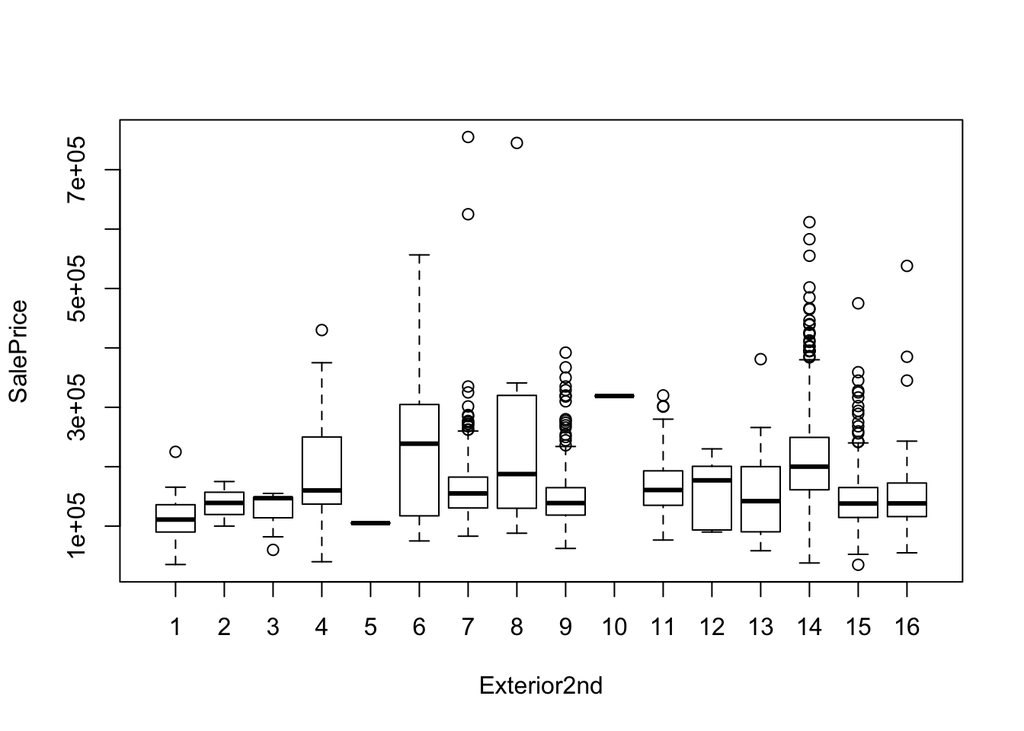

```r
  # Starting with Exterior2nd.
  # The factors are "AsbShng" "AsphShn" "Brk Cmn" "BrkFace" "CBlock"  "CmentBd" "HdBoard" "ImStucc" "MetalSd" "Plywood" "Stone"   "Stucco"  "VinylSd" "Wd Sdng" "Wd Shng"

plot(SalePrice ~ Exterior2nd, data = houses)
```

```r
houses %>%
  group_by(Exterior2nd) %>%
  summarize(MedianSale = median(SalePrice)) %>%
  arrange(MedianSale) %>%
  pander()
```

| Exterior2nd | MedianSale |
| --- | --- |
| 5 | 105000 |
| 1 | 111000 |
| 15 | 138000 |
| 16 | 138225 |
| 9 | 138750 |
| 2 | 139000 |
| 13 | 142000 |
| 3 | 147000 |
| 7 | 155000 |
| 4 | 160000 |
| 11 | 160750 |
| 12 | 177000 |
| 8 | 187600 |
| 14 | 200070 |
| 6 | 238750 |
| 10 | 319000 |

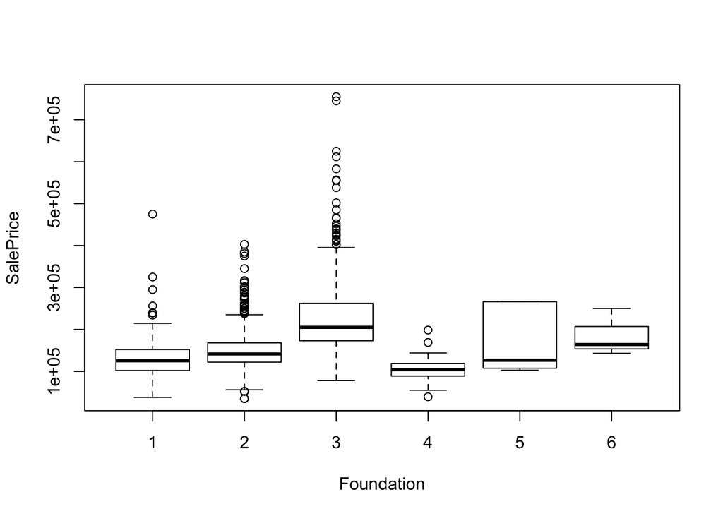

```r
# Moving on to Foundation.
# The factors are "BrkTil" "CBlock" "PConc"  "Slab"   "Stone"  "Wood"

plot(SalePrice ~ Foundation, data = houses)
```

```r
houses %>%
  group_by(Foundation) %>%
  summarize(MedianSale = median(SalePrice)) %>%
  arrange(MedianSale) %>%
  pander()
```

| Foundation | MedianSale |
| --- | --- |
| 4 | 104150 |
| 1 | 125250 |
| 5 | 126500 |
| 2 | 141500 |
| 6 | 164000 |
| 3 | 205000 |

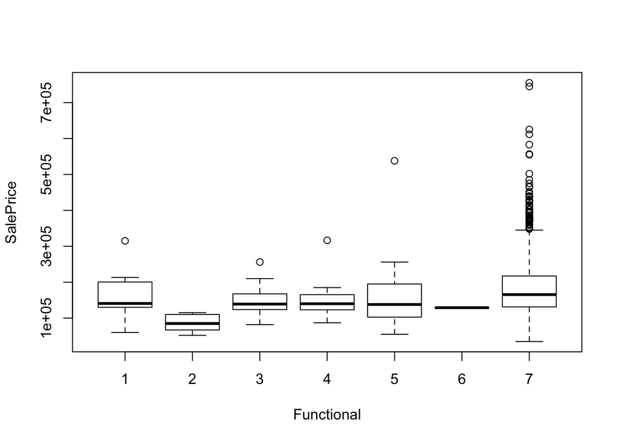

```r
# Moving on to Functional
# The factors are "Maj1" "Maj2" "Min1" "Min2" "Mod"  "Sev"  "Typ"

plot(SalePrice ~ Functional, data = houses)
```

```r
houses %>%
  group_by(Functional) %>%
  summarize(MedianSale = median(SalePrice)) %>%
  arrange(MedianSale) %>%
  pander()
```

| Functional | MedianSale |
| --- | --- |
| 2 | 85000 |
| 6 | 129000 |
| 5 | 137900 |
| 3 | 139000 |
| 4 | 140000 |
| 1 | 140750 |
| 7 | 165500 |

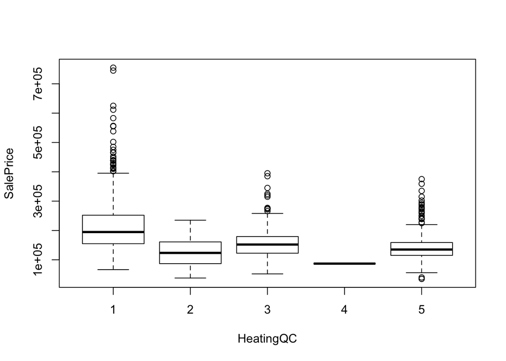

```r
# Moving on to HeatingQC
# The factors are "Ex" "Fa" "Gd" "Po" "TA"

plot(SalePrice ~ HeatingQC, data = houses)
```

```r
houses %>%
  group_by(HeatingQC) %>%
  summarize(MedianSale = median(SalePrice)) %>%
  arrange(MedianSale) %>%
  pander()
```

| HeatingQC | MedianSale |
| --- | --- |
| 4 | 87000 |
| 2 | 123500 |
| 5 | 135000 |
| 3 | 152000 |
| 1 | 194700 |

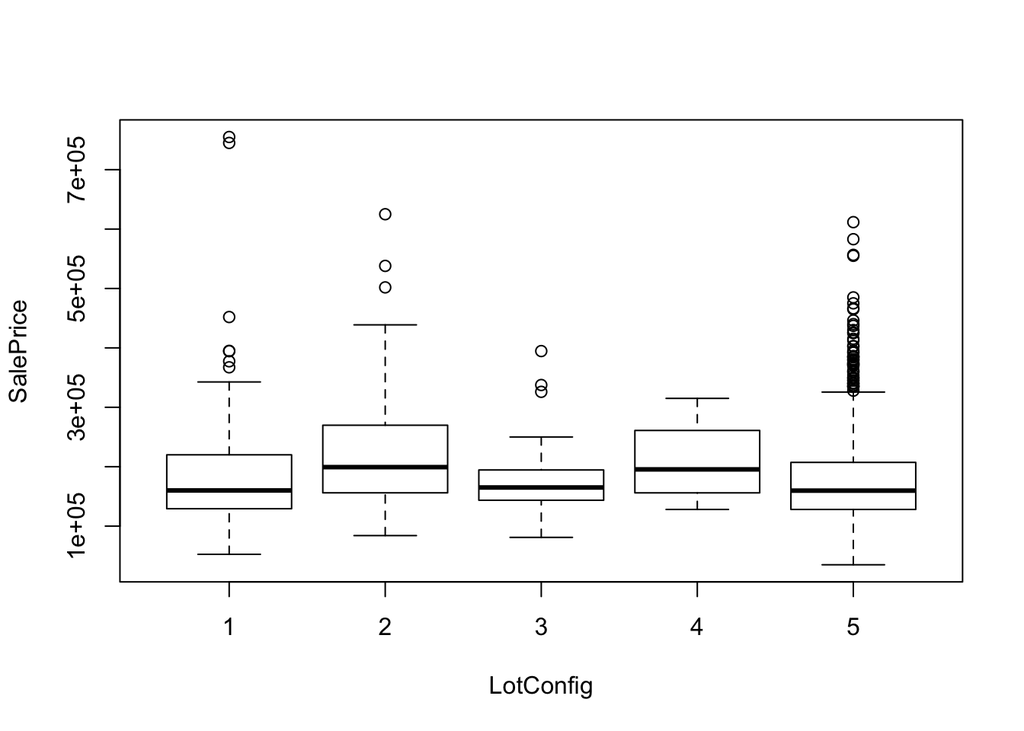

```r
# Moving on to LotConfig
# The factors are "Corner"  "CulDSac" "FR2"     "FR3"     "Inside"

plot(SalePrice ~ LotConfig, data = houses)
```

```r
houses %>%
  group_by(LotConfig) %>%
  summarize(MedianSale = median(SalePrice)) %>%
  arrange(MedianSale) %>%
  pander()
```

| LotConfig | MedianSale |
| --- | --- |
| 5 | 159698 |
| 1 | 160000 |
| 3 | 165000 |
| 4 | 195450 |
| 2 | 199262 |

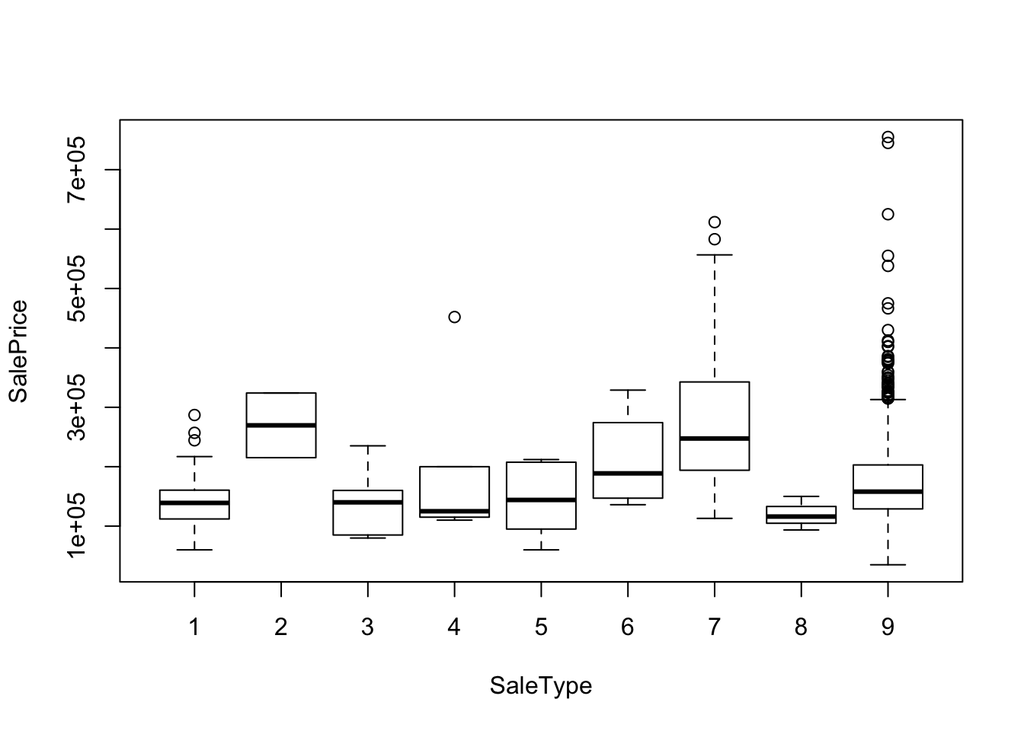

```r
# Moving on to SaleType
# The factors are "COD"   "Con"   "ConLD" "ConLI" "ConLw" "CWD"   "New"   "Oth"   "WD"

plot(SalePrice ~ SaleType, data = houses)
```

```r
houses %>%
  group_by(SaleType) %>%
  summarize(MedianSale = median(SalePrice)) %>%
  arrange(MedianSale) %>%
  pander()
```

| SaleType | MedianSale |
| --- | --- |
| 8 | 116050 |
| 4 | 125000 |
| 1 | 139000 |
| 3 | 140000 |
| 5 | 144000 |
| 9 | 158000 |
| 6 | 188750 |
| 7 | 247453 |
| 2 | 269600 |

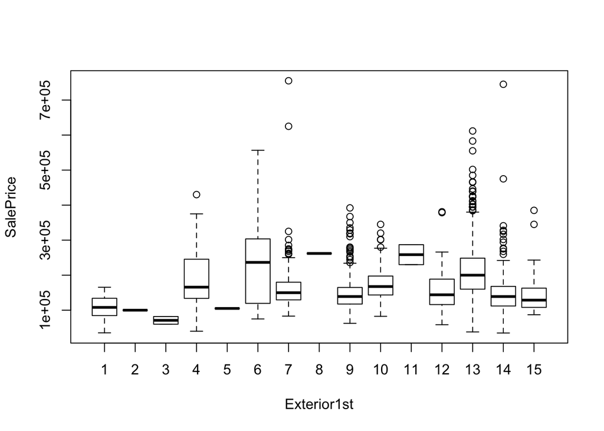

```r
# Moving on to Exterior1st
# The factors are "AsbShng" "AsphShn" "Brk Cmn" "BrkFace" "CBlock"  "CmentBd" "HdBoard" "ImStucc" "MetalSd" "Other"   "Plywood" "Stone"   "Stucco"  "VinylSd" "WdSdng" "WdShng"

plot(SalePrice ~ Exterior1st, data = houses)
```

```r
houses %>%
  group_by(Exterior1st) %>%
  summarize(MedianSale = median(SalePrice)) %>%
  arrange(MedianSale) %>%
  pander()
```

| Exterior1st | MedianSale |
| --- | --- |
| 3 | 71000 |
| 2 | 1e+05 |
| 5 | 105000 |
| 1 | 108000 |
| 15 | 128700 |
| 14 | 138944 |
| 9 | 139000 |
| 12 | 144000 |
| 7 | 149900 |
| 4 | 165750 |
| 10 | 167450 |
| 13 | 2e+05 |
| 6 | 236500 |
| 11 | 258500 |
| 8 | 262000 |

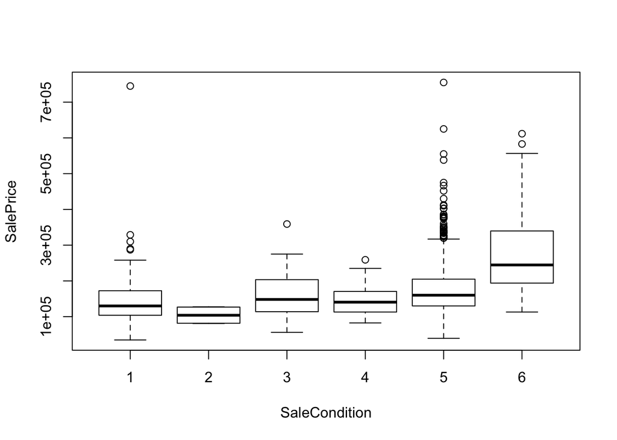

```r
# Moving on to SaleCondition
# The factors are "Abnorml" "AdjLand" "Alloca"  "Family"  "Normal"  "Partial"

plot(SalePrice ~ SaleCondition, data = houses)
```

```r
houses %>%
  group_by(SaleCondition) %>%
  summarize(MedianSale = median(SalePrice)) %>%
  arrange(MedianSale) %>%
  pander()
```

| SaleCondition | MedianSale |
| --- | --- |
| 2 | 104000 |
| 1 | 130000 |
| 4 | 140500 |
| 3 | 148145 |
| 5 | 160000 |
| 6 | 244600 |

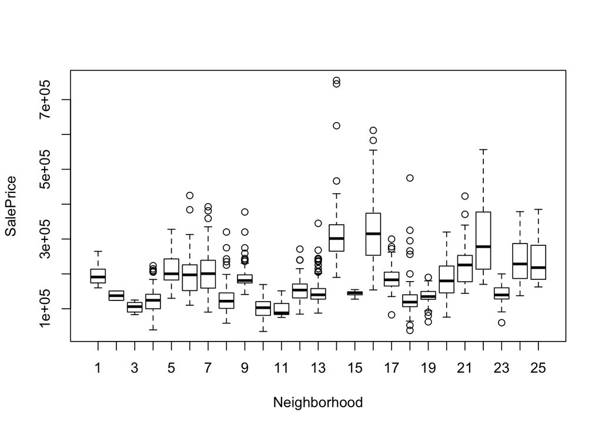

```r
# Moving on to Neighborhood
# The factors are "Blmngtn" "Blueste" "BrDale"  "BrkSide" "ClearCr" "CollgCr" "Crawfor" "Edwards" "Gilbert" "IDOTRR"  "MeadowV" "Mitchel" "NAmes"   "NoRidge" "NPkVill" "NridgHt" "NWAmes"  "OldTown" "Sawyer"  "SawyerW" "Somerst" "StoneBr" "SWISU"   "Timber"  "Veenker"

plot(SalePrice ~ Neighborhood, data = houses)
```

```r
houses %>%
  group_by(Neighborhood) %>%
  summarize(MedianSale = median(SalePrice)) %>%
  arrange(MedianSale) %>%
  pander()
```

| Neighborhood | MedianSale |
| --- | --- |
| 11 | 88000 |
| 10 | 103000 |
| 3 | 106000 |
| 18 | 119000 |
| 8 | 121750 |
| 4 | 124300 |
| 19 | 135000 |
| 2 | 137500 |
| 23 | 139500 |
| 13 | 140000 |
| 15 | 146000 |
| 12 | 153500 |
| 20 | 179900 |
| 9 | 181000 |
| 17 | 182900 |
| 1 | 191000 |
| 6 | 197200 |
| 5 | 200250 |
| 7 | 200624 |
| 25 | 218000 |
| 21 | 225500 |
| 24 | 228475 |
| 22 | 278000 |
| 14 | 301500 |
| 16 | 315000 |

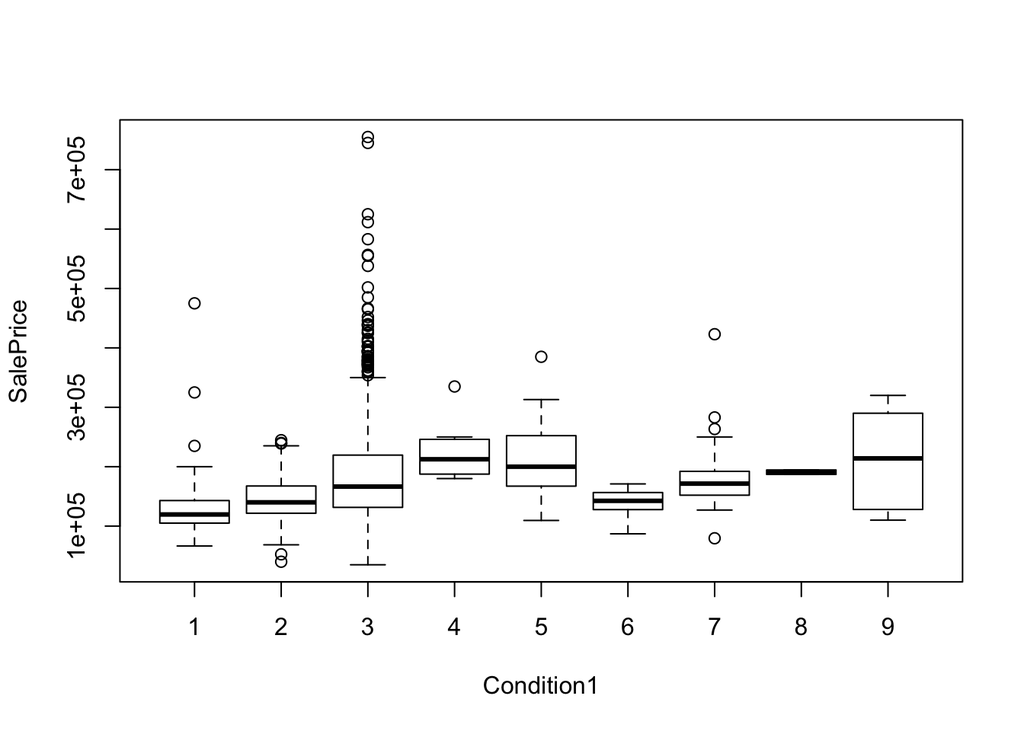

```r
# Moving on to Condition1
# The factors are "Artery" "Feedr"  "Norm"   "PosA"   "PosN"   "RRAe"   "RRAn"   "RRNe"   "RRNn"

plot(SalePrice ~ Condition1, data = houses)
```

```r
houses %>%
  group_by(Condition1) %>%
  summarize(MedianSale = median(SalePrice)) %>%
  arrange(MedianSale) %>%
  pander()
```

| Condition1 | MedianSale |
| --- | --- |
| 1 | 119550 |
| 2 | 140000 |
| 6 | 142500 |
| 3 | 166500 |
| 7 | 171495 |
| 8 | 190750 |
| 5 | 2e+05 |
| 4 | 212500 |
| 9 | 214000 |

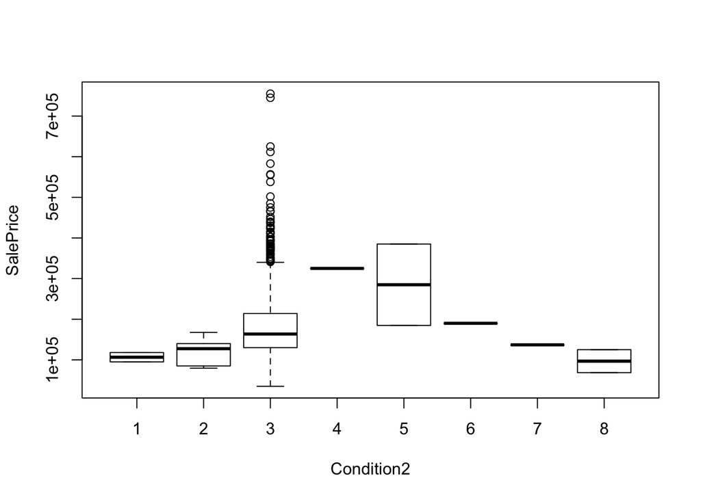

```r
# Moving on to Condition2
# The factors are "Artery" "Feedr"  "Norm"   "PosA"   "PosN"   "RRAe"   "RRAn"   "RRNn"

plot(SalePrice ~ Condition2, data = houses)
```

```r
houses %>%
  group_by(Condition2) %>%
  summarize(MedianSale = median(SalePrice)) %>%
  arrange(MedianSale) %>%
  pander()
```

| Condition2 | MedianSale |
| --- | --- |
| 8 | 96750 |
| 1 | 106500 |
| 2 | 127500 |
| 7 | 136905 |
| 3 | 163500 |
| 6 | 190000 |
| 5 | 284875 |
| 4 | 325000 |

Deciding that things were getting a little too sticky to show graphically and to interpret. I’ve decided to take different components learned in my model, graphs, and tables above. See “Chosen Model” and “Graphical Support” tabs for the model that I settled into, its Adjusted R-squared/validation, and it’s supporting graphs.

### Chosen Model

#### The Model

The model that I have chosen is the following.

```r
# training_set <- training_set %>%
#   mutate(BsmtQual = replace_na(BsmtQual,"3"))

# which(rownames(training_set) %in% c(31, 496, 524))

regressor3 <- lm(log(SalePrice) ~ X2ndFlrSF + BsmtFinSF1 + CentralAir + LotArea + BsmtUnfSF + YearBuilt + HeatingQC_Ta + GarageArea + OverallQual:I(X1stFlrSF^2) + OverallCond:I(X1stFlrSF^2) + Fireplaces + OverallQual:X1stFlrSF, data = training_set)

summary(regressor3)
```

```
##
## Call:
## lm(formula = log(SalePrice) ~ X2ndFlrSF + BsmtFinSF1 + CentralAir +
##     LotArea + BsmtUnfSF + YearBuilt + HeatingQC_Ta + GarageArea +
##     OverallQual:I(X1stFlrSF^2) + OverallCond:I(X1stFlrSF^2) +
##     Fireplaces + OverallQual:X1stFlrSF, data = training_set)
##
## Residuals:
##      Min       1Q   Median       3Q      Max
## -1.01259 -0.06893  0.00622  0.08000  0.56590
##
## Coefficients:
##                              Estimate Std. Error t value Pr(>|t|)
## (Intercept)                 5.756e+00  3.555e-01  16.190  < 2e-16 ***
## X2ndFlrSF                   2.752e-04  1.019e-05  27.008  < 2e-16 ***
## BsmtFinSF1                  1.465e-04  1.646e-05   8.898  < 2e-16 ***
## CentralAir2                 1.171e-01  1.816e-02   6.448 1.62e-10 ***
## LotArea                     2.418e-06  4.148e-07   5.828 7.12e-09 ***
## BsmtUnfSF                   4.994e-05  1.577e-05   3.167  0.00158 **
## YearBuilt                   2.636e-03  1.852e-04  14.234  < 2e-16 ***
## HeatingQC_Ta               -5.377e-02  9.602e-03  -5.600 2.64e-08 ***
## GarageArea                  2.054e-04  2.543e-05   8.077 1.55e-15 ***
## Fireplaces                  3.333e-02  7.487e-03   4.451 9.31e-06 ***
## OverallQual:I(X1stFlrSF^2) -3.812e-08  1.413e-09 -26.979  < 2e-16 ***
## I(X1stFlrSF^2):OverallCond  1.751e-08  1.844e-09   9.499  < 2e-16 ***
## OverallQual:X1stFlrSF       1.197e-04  3.605e-06  33.208  < 2e-16 ***
## ---
## Signif. codes:  0 '***' 0.001 '**' 0.01 '*' 0.05 '.' 0.1 ' ' 1
##
## Residual standard error: 0.1421 on 1245 degrees of freedom
## Multiple R-squared:  0.8816, Adjusted R-squared:  0.8804
## F-statistic: 772.2 on 12 and 1245 DF,  p-value: < 2.2e-16
```

```r
b <- regressor3$coefficients
```

Let take a quick look at the Residuals vs Fitted Plot.

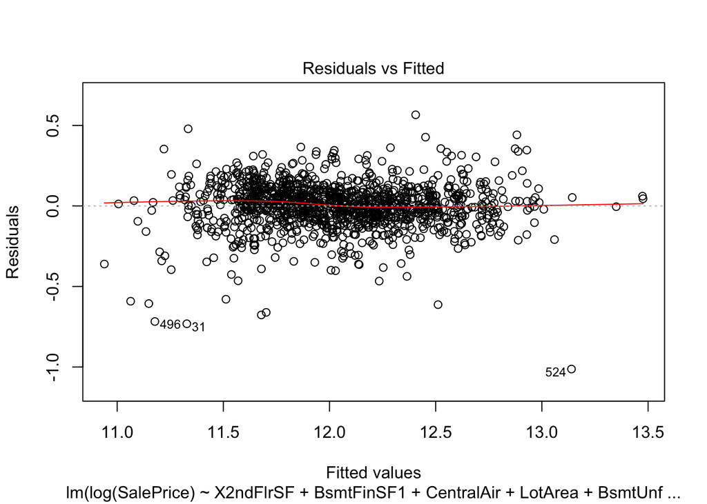

```r
plot(regressor3, which = 1)
```

Things look good here. A few outliers, but they don’t seem to affect things very much.

#### The Validation

The following Table gives the validation of the above model.

```r
#apply(test_set1, 2, function(x) sum(is.na(x)))

# test_set <- test_set %>%
#   mutate(BsmtQual = replace_na(BsmtQual,"3"))

y_pred <- exp(predict(regressor3, newdata = test_set))

test_set2 <- cbind(test_set, y_pred) %>%
  select(SalePrice, y_pred)

ybar <- mean(test_set2$SalePrice)
SSTO <- sum( (test_set2$SalePrice - ybar)^2 )
SSE <- sum( (test_set2$SalePrice - test_set2$y_pred)^2 )
rs <- 1 - SSE/SSTO
n <- length(test_set2$SalePrice)
p <- length(coef(regressor3))
rsa <- 1 - (n-1)/(n-p)*SSE/SSTO
```

| Validation | $R^2$ | Adjusted $R^2$ |
| --- | --- | --- |
| Model | 0.8528688 | 0.8435272 |

### Graphical Support

Alright, here we go. The pair plot below gives us a starting point to begin looking at how each of the variables chosen in my model look against each other, but especially against the SalesPrice.

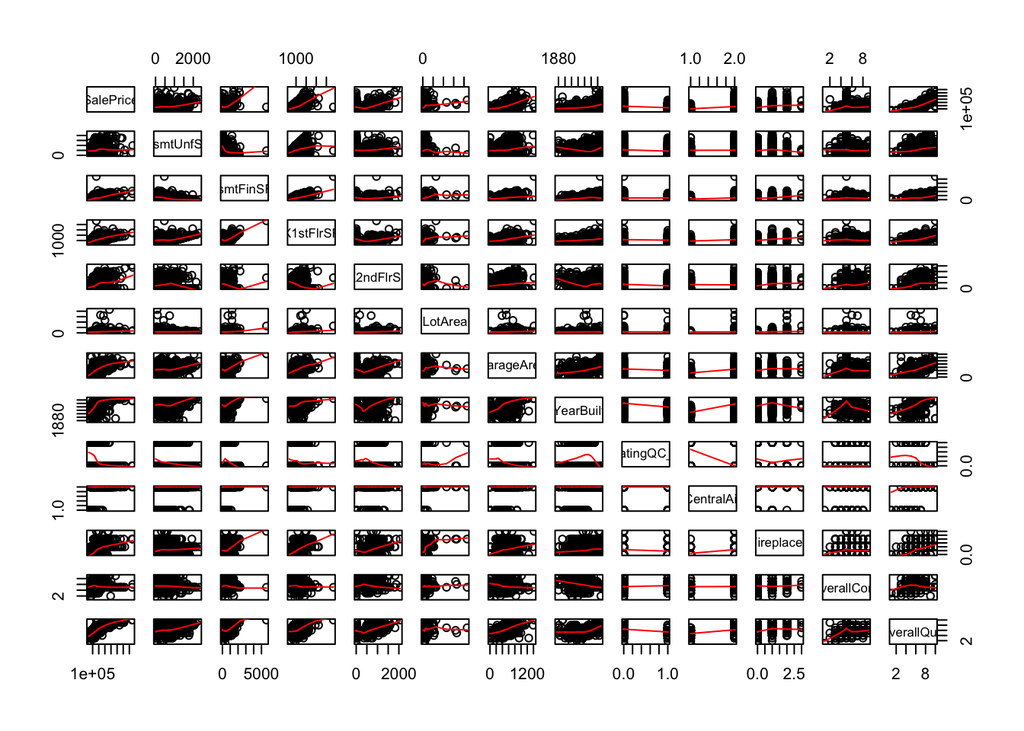

```r
pairs(training_set[,c("SalePrice", "BsmtUnfSF", "BsmtFinSF1", "X1stFlrSF", "X2ndFlrSF", "LotArea", "GarageArea", "YearBuilt", "HeatingQC_Ta", "CentralAir", "Fireplaces", "OverallCond", "OverallQual")], panel=panel.smooth)
```

```r
training_set %>%
  select(BsmtUnfSF, BsmtFinSF1, X1stFlrSF, X2ndFlrSF, LotArea, GarageArea, YearBuilt, Fireplaces, OverallQual, OverallCond) %>%
  summarise_each(funs(min = min,
                      q25 = quantile(., 0.25),
                      median = median,
                      q75 = quantile(., 0.75),
                      max = max,
                      mean = mean)) %>%
  gather(stat, val) %>%
  separate(stat, into = c("var", "stat"), sep = "_") %>%
  spread(stat, val) %>%
  select(var, min, q25, median, q75, max, mean) %>%
  pander()
```

| var | min | q25 | median | q75 | max | mean |
| --- | --- | --- | --- | --- | --- | --- |
| BsmtFinSF1 | 0 | 0 | 382 | 716 | 5644 | 447.3 |
| BsmtUnfSF | 0 | 237.2 | 481.5 | 809.5 | 2336 | 572.3 |
| Fireplaces | 0 | 0 | 1 | 1 | 3 | 0.6272 |
| GarageArea | 0 | 336 | 479.5 | 577.8 | 1418 | 476.9 |
| LotArea | 1300 | 7579 | 9544 | 11614 | 215245 | 10551 |
| OverallCond | 1 | 5 | 5 | 6 | 9 | 5.591 |
| OverallQual | 1 | 5 | 6 | 7 | 10 | 6.155 |
| X1stFlrSF | 334 | 882 | 1092 | 1414 | 4692 | 1171 |
| X2ndFlrSF | 0 | 0 | 0 | 741 | 2065 | 354.4 |
| YearBuilt | 1875 | 1953 | 1973 | 2001 | 2010 | 1972 |

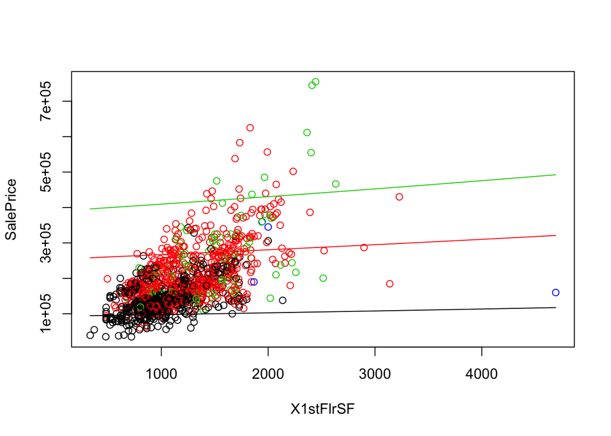

```r
plot(SalePrice ~ X1stFlrSF, data=training_set, col=as.factor(Fireplaces))

BsmtFinSF1=0;X1stFlrSF=882;X2ndFlrSF=0;LotArea=7579;GarageArea=336;YearBuilt=1953;
CentralAir2=0;Fireplaces=0;HeatingQC_Ta=0;OverallQual=5;OverallCond=5;

curve(exp(b[1] + b[2]*X2ndFlrSF + b[3]*BsmtFinSF1 + b[4]*CentralAir2 + b[5]*LotArea + b[6]*BsmtUnfSF + b[7]*YearBuilt + b[8]*HeatingQC_Ta + b[9]*GarageArea + b[10]*Fireplaces + b[11]*OverallQual*X1stFlrSF^2 + b[12]*OverallCond*X1stFlrSF^2 + b[13]*OverallQual*X1stFlrSF), add=TRUE, xname="BsmtUnfSF", col=palette()[1])

BsmtFinSF1=716;X1stFlrSF=1414;X2ndFlrSF=741;LotArea=11614;GarageArea=578;YearBuilt=2001;
CentralAir2=1;Fireplaces=1;HeatingQC_Ta=1;OverallQual=7;OverallCond=6;
curve(exp(b[1] + b[2]*X2ndFlrSF + b[3]*BsmtFinSF1 + b[4]*CentralAir2 + b[5]*LotArea + b[6]*BsmtUnfSF + b[7]*YearBuilt + b[8]*HeatingQC_Ta + b[9]*GarageArea + b[10]*Fireplaces + b[11]*OverallQual*X1stFlrSF^2 + b[12]*OverallCond*X1stFlrSF^2 + b[13]*OverallQual*X1stFlrSF), add=TRUE, xname="BsmtUnfSF", col=palette()[2])

BsmtFinSF1=716;X1stFlrSF=4692;X2ndFlrSF=2065;LotArea=11614;GarageArea=1418;YearBuilt=2010;
CentralAir2=1;Fireplaces=2;HeatingQC_Ta=1;OverallQual=10;OverallCond=9;
curve(exp(b[1] + b[2]*X2ndFlrSF + b[3]*BsmtFinSF1 + b[4]*CentralAir2 + b[5]*LotArea + b[6]*BsmtUnfSF + b[7]*YearBuilt + b[8]*HeatingQC_Ta + b[9]*GarageArea + b[10]*Fireplaces + b[11]*OverallQual*X1stFlrSF^2 + b[12]*OverallCond*X1stFlrSF^2 + b[13]*OverallQual*X1stFlrSF), add=TRUE, xname="BsmtUnfSF", col=palette()[3])
```

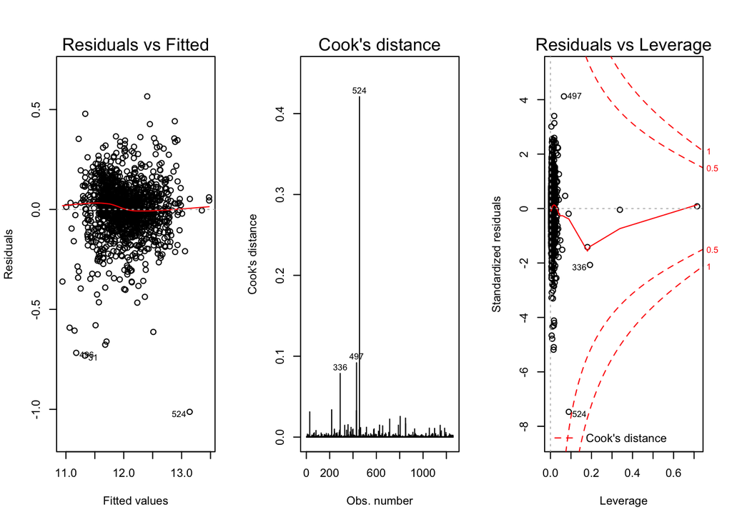

```r
par(mfrow=c(1,3))

plot(regressor3, which=c(1,4,5))
```

It would appear that point 524 is an outlier and could be removed from the regression.